# Visualisation of Email Observation Data

Exploring the Email Observation Form Through Three Plots

Hillyn Liu

## Plot for the First and Last Email Time Difference Everyday

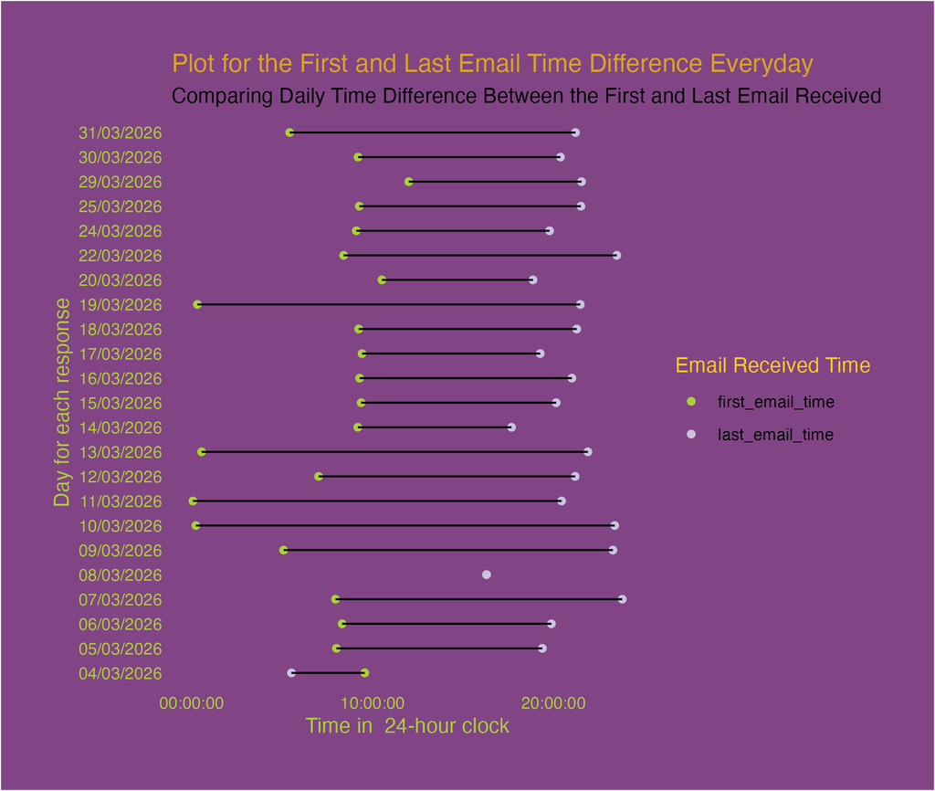

My data in Plot1 are based on the times (in 24 hour clock) for the emails received and the dates which are specific for the emails. This is a dot plot with a line. I am analyzing when the first and last email were usually received in my email box and I use a line to connect these two timings to see how long I would received emails for each day. The dates are put in y-axis and the times are in axis, these can help me better compare each day with the time difference. The plot shows about 20 days of data.

## Bar chart for Number of Days with Study-Related Emails in Weekday and Weekend Categories

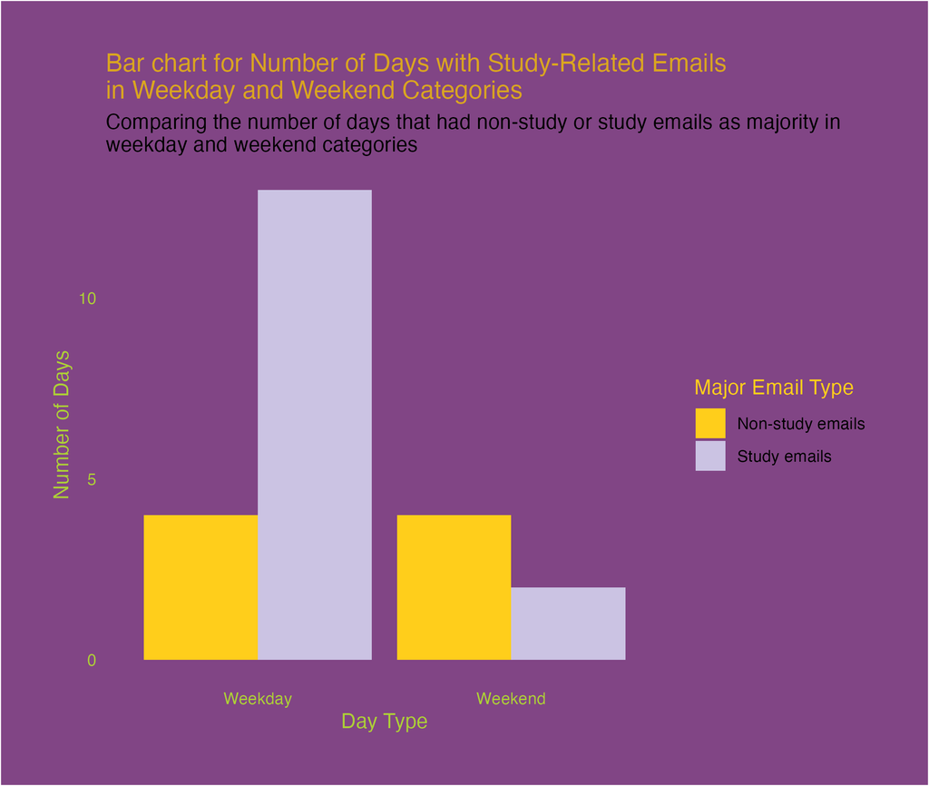

My data in Plot2 are categorical and numeric. The categorical data are classifying the emails received days into either weekday or weekend. The numeric is the number of days that are either with study emails or with non-study emails mainly. I am analyzing how many emails related to study I would receive in weekday and weekend and compare these in the same type of days (like compare within the weekday category itself) or in different type of days (like compare weekday with weekend). The bar chart shows about 20 days of data.

## Plot for the Number of Emails Received in Different Days

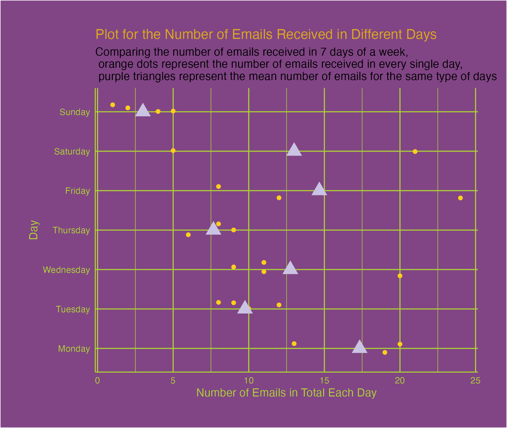

This is a visualization with the use of (jitter) dot plot. The data are based on the numeric variable (number of emails) and categorical variable (days of a week). I am analysing for 7 different types of days in one week, how the number of emails received in total in my mail box varies. The mean number of emails received is represented by a different shape (triangle) produces valid data points as a reference to compare different days without the impact of extreme data. The plot shows about 20 days of data.